# Assignment-03.Rmd

Bethany Riess

August 15, 2020

```r
library(tidyverse)
library(lattice)
library(kableExtra)
library(markdown)
library(rmarkdown)

knitr::opts_chunk$set(echo = FALSE)
```

## Three-spined stickelbacks

Three spined stickelbacks (*Gasterosteus aculeatus*) are fish native to most inland coastal water. They are easy to find in nature and useful for studies on evolution and social behavior, amongst other things. Mature Three-spined Stickelbacks usually reach 3 to 4 centimeters in length but can reach up to 8 cm. The three spines in front of its dorsal fin are where the fish gets its name.

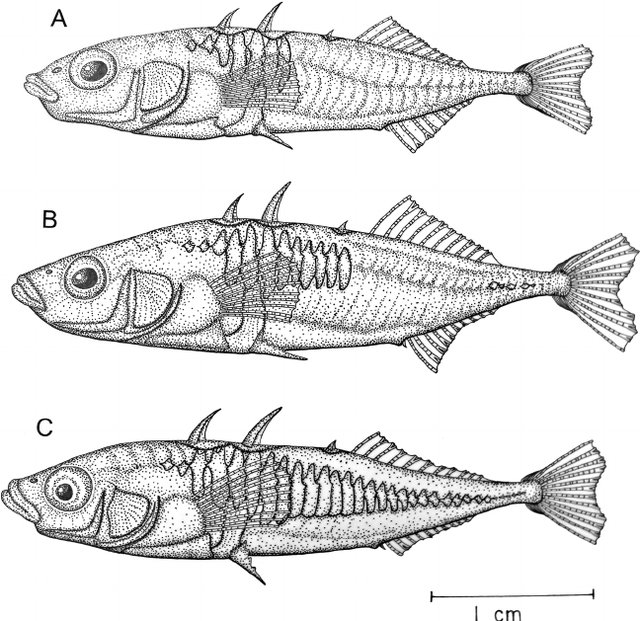

```
## $caption
## [1] "**Figure 1**: Lateral plate morphology of the three-spine stickleback. © Windsor E. Aguirre"
##
## attr(,"class")
## [1] "labels"
```

## Hardy Weinberg conditions

The Hardy-Weinberg principal is a principle in genetics that states that allele and genotype frequencies in a population will remain constant from generation to generation in the absence of other evolutionary influences such as mutation, gene-flow, and natural selection. The equation that accompanys this theory is $p^2^ + 2pq + q^2^ = 1$.

## Data analyses

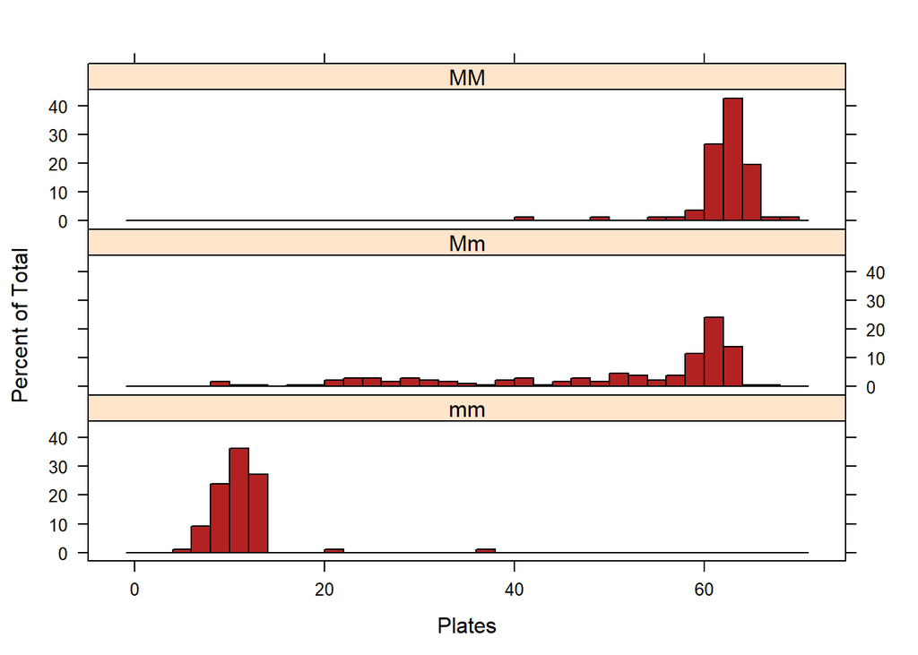

```
## [1] "**Figure 2**: Frequency distribution of lateral plate counts by genotype"
```

The histogram above shows the percents of total fish counted at each plate.

| Genotype | N | Mean | Median | StdDev |
| --- | --- | --- | --- | --- |
| mm | 88 | 11.67 | 11 | 3.57 |
| Mm | 174 | 50.38 | 59 | 15.15 |
| MM | 82 | 62.78 | 63 | 3.41 |

```
## [1] "**Table 1**: Summary of lateral plate numbers by genotype"
```

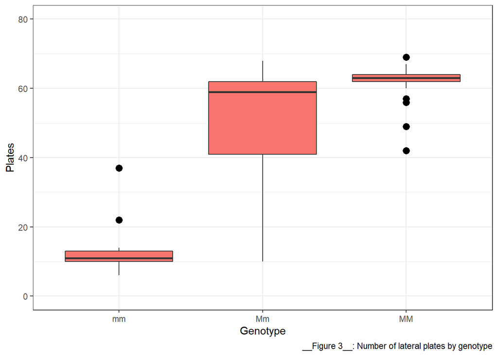

Figure 3 demonstrates how Three-spined stickelback with the genotype mm have the least amount of lateral plates, while those with the genotype MM typically have the most lateral plates. The genotype Mm falls in between with the number of lateral plates ranging between that of MM and mm.

**Table 2:** One-way ANOVA analysis of lateral plate numbers by genotype.

|  | Df | Sum Sq | Mean Sq | F value | Pr(>F) |
| --- | --- | --- | --- | --- | --- |
| Genotype | 2 | 127870.01 | 63935.002 | 522.319 | 0 |
| Residuals | 341 | 41740.46 | 122.406 | NA | NA |

## Conclusions

In conclusion, the most common genotype for Three-spined stickelbacks is Mm, but fish with the mm genotype have significantly less lateral plates than the fish with Mm, and the fish with MM have more than the other two genotypes.

## Reference

Colosimo, P. F., Peichel, C. L., Nereng, K., Blackman, B. K., Shapiro, M. D., Schluter, D., & Kingsley, D. M. (2004). *The Genetic Architecture of Parallel Armor Plate Reduction in Threespine Sticklebacks.* PLoS Biology, 2(5), e109. https://doi.org/10.1371/journal.pbio.0020109